# House Price Prediction

https://gist.github.com/satkr7/219ef0497f8cb7f717820508dd97cc10#file-mulitple_models_with_gridsearchcv-ipynb

#### Predict sales prices

Ask a home buyer to describe their dream house, and they probably won't begin with the height of the basement ceiling or the proximity to an east-west railroad. But this playground competition's dataset proves that much more influences price negotiations than the number of bedrooms or a white-picket fence.

With 79 explanatory variables describing (almost) every aspect of residential homes in Ames, Iowa, this competition challenges you to predict the final price of each home.

Goal

It is your job to predict the sales price for each house. For each Id in the test set, you must predict the value of the SalePrice variable.

Metric

Submissions are evaluated on Root-Mean-Squared-Error (RMSE) between the logarithm of the predicted value and the logarithm of the observed sales price. (Taking logs means that errors in predicting expensive houses and cheap houses will affect the result equally.)

Submission File Format

The file should contain a header and have the following format:

Id,SalePrice

1461,169000.1

1462,187724.1233

1463,175221

etc.

Il ne faut pas que je touche le test set.

J'ai vu qu'il avait des données manquantes, mais je dois ne rien toucher pour ne pas faire du data leakage, corrompre mon fichier...

Il faut que je fasse une pipeline dans laquelle je mets tout le feature engineering necessaire au train set et donc par le suite à de nouvelles données (test set).

Il faut que je fasse la même API que j'ai faite pour la détéction de fraudes bancaires.

## Librairies Importation

```python
import pandas as pd
import numpy as np
import matplotlib.pyplot as plt
import seaborn as sns

import warnings
warnings.filterwarnings("ignore")
```

## Dataset Importation

```python
train = pd.read_csv("train.csv")
test = pd.read_csv("test.csv")
sample_submission = pd.read_csv("sample_submission.csv")
```

## Exploratory Data Analysis

### Overview

```python
print(train.shape)
print("\n")
print(test.shape)
```

```
(1460, 81)


(1459, 80)
```

```python
train.head()
```

|  | Id | MSSubClass | MSZoning | LotFrontage | LotArea | Street | Alley | LotShape | LandContour | Utilities | LotConfig | LandSlope | Neighborhood | Condition1 | Condition2 | BldgType | HouseStyle | OverallQual | OverallCond | YearBuilt | YearRemodAdd | RoofStyle | RoofMatl | Exterior1st | Exterior2nd | MasVnrType | MasVnrArea | ExterQual | ExterCond | … |
| --- | --- | --- | --- | --- | --- | --- | --- | --- | --- | --- | --- | --- | --- | --- | --- | --- | --- | --- | --- | --- | --- | --- | --- | --- | --- | --- | --- | --- | --- | --- |
| 0 | 1 | 60 | RL | 65.0 | 8450 | Pave | NaN | Reg | Lvl | AllPub | Inside | Gtl | CollgCr | Norm | Norm | 1Fam | 2Story | 7 | 5 | 2003 | 2003 | Gable | CompShg | VinylSd | VinylSd | BrkFace | 196.0 | Gd | TA | … |
| 1 | 2 | 20 | RL | 80.0 | 9600 | Pave | NaN | Reg | Lvl | AllPub | FR2 | Gtl | Veenker | Feedr | Norm | 1Fam | 1Story | 6 | 8 | 1976 | 1976 | Gable | CompShg | MetalSd | MetalSd | None | 0.0 | TA | TA | … |
| 2 | 3 | 60 | RL | 68.0 | 11250 | Pave | NaN | IR1 | Lvl | AllPub | Inside | Gtl | CollgCr | Norm | Norm | 1Fam | 2Story | 7 | 5 | 2001 | 2002 | Gable | CompShg | VinylSd | VinylSd | BrkFace | 162.0 | Gd | TA | … |
| 3 | 4 | 70 | RL | 60.0 | 9550 | Pave | NaN | IR1 | Lvl | AllPub | Corner | Gtl | Crawfor | Norm | Norm | 1Fam | 2Story | 7 | 5 | 1915 | 1970 | Gable | CompShg | Wd Sdng | Wd Shng | None | 0.0 | TA | TA | … |
| 4 | 5 | 60 | RL | 84.0 | 14260 | Pave | NaN | IR1 | Lvl | AllPub | FR2 | Gtl | NoRidge | Norm | Norm | 1Fam | 2Story | 8 | 5 | 2000 | 2000 | Gable | CompShg | VinylSd | VinylSd | BrkFace | 350.0 | Gd | TA | … |

```python
test.head()
```

|  | Id | MSSubClass | MSZoning | LotFrontage | LotArea | Street | Alley | LotShape | LandContour | Utilities | LotConfig | LandSlope | Neighborhood | Condition1 | Condition2 | BldgType | HouseStyle | OverallQual | OverallCond | YearBuilt | YearRemodAdd | RoofStyle | RoofMatl | Exterior1st | Exterior2nd | MasVnrType | MasVnrArea | ExterQual | ExterCond | … |
| --- | --- | --- | --- | --- | --- | --- | --- | --- | --- | --- | --- | --- | --- | --- | --- | --- | --- | --- | --- | --- | --- | --- | --- | --- | --- | --- | --- | --- | --- | --- |
| 0 | 1461 | 20 | RH | 80.0 | 11622 | Pave | NaN | Reg | Lvl | AllPub | Inside | Gtl | NAmes | Feedr | Norm | 1Fam | 1Story | 5 | 6 | 1961 | 1961 | Gable | CompShg | VinylSd | VinylSd | None | 0.0 | TA | TA | … |
| 1 | 1462 | 20 | RL | 81.0 | 14267 | Pave | NaN | IR1 | Lvl | AllPub | Corner | Gtl | NAmes | Norm | Norm | 1Fam | 1Story | 6 | 6 | 1958 | 1958 | Hip | CompShg | Wd Sdng | Wd Sdng | BrkFace | 108.0 | TA | TA | … |
| 2 | 1463 | 60 | RL | 74.0 | 13830 | Pave | NaN | IR1 | Lvl | AllPub | Inside | Gtl | Gilbert | Norm | Norm | 1Fam | 2Story | 5 | 5 | 1997 | 1998 | Gable | CompShg | VinylSd | VinylSd | None | 0.0 | TA | TA | … |
| 3 | 1464 | 60 | RL | 78.0 | 9978 | Pave | NaN | IR1 | Lvl | AllPub | Inside | Gtl | Gilbert | Norm | Norm | 1Fam | 2Story | 6 | 6 | 1998 | 1998 | Gable | CompShg | VinylSd | VinylSd | BrkFace | 20.0 | TA | TA | … |
| 4 | 1465 | 120 | RL | 43.0 | 5005 | Pave | NaN | IR1 | HLS | AllPub | Inside | Gtl | StoneBr | Norm | Norm | TwnhsE | 1Story | 8 | 5 | 1992 | 1992 | Gable | CompShg | HdBoard | HdBoard | None | 0.0 | Gd | TA | … |

```python
sample_submission.head()
```

|  | Id | SalePrice |
| --- | --- | --- |
| 0 | 1461 | 169277.052498 |
| 1 | 1462 | 187758.393989 |
| 2 | 1463 | 183583.683570 |
| 3 | 1464 | 179317.477511 |
| 4 | 1465 | 150730.079977 |

### Stats

```python
pd.set_option('display.max_columns', None)
train.describe().round(2)
```

|  | Id | MSSubClass | LotFrontage | LotArea | OverallQual | OverallCond | YearBuilt | YearRemodAdd | MasVnrArea | BsmtFinSF1 | BsmtFinSF2 | BsmtUnfSF | TotalBsmtSF | 1stFlrSF | 2ndFlrSF | LowQualFinSF | GrLivArea | BsmtFullBath | BsmtHalfBath | FullBath | HalfBath | BedroomAbvGr | KitchenAbvGr | TotRmsAbvGrd | Fireplaces | GarageYrBlt | GarageCars | GarageArea | WoodDeckSF | … |
| --- | --- | --- | --- | --- | --- | --- | --- | --- | --- | --- | --- | --- | --- | --- | --- | --- | --- | --- | --- | --- | --- | --- | --- | --- | --- | --- | --- | --- | --- | --- |
| count | 1460.00 | 1460.0 | 1201.00 | 1460.00 | 1460.00 | 1460.00 | 1460.00 | 1460.00 | 1452.00 | 1460.00 | 1460.00 | 1460.00 | 1460.00 | 1460.00 | 1460.00 | 1460.00 | 1460.00 | 1460.00 | 1460.00 | 1460.00 | 1460.00 | 1460.00 | 1460.00 | 1460.00 | 1460.00 | 1379.00 | 1460.00 | 1460.00 | 1460.00 | … |
| mean | 730.50 | 56.9 | 70.05 | 10516.83 | 6.10 | 5.58 | 1971.27 | 1984.87 | 103.69 | 443.64 | 46.55 | 567.24 | 1057.43 | 1162.63 | 346.99 | 5.84 | 1515.46 | 0.43 | 0.06 | 1.57 | 0.38 | 2.87 | 1.05 | 6.52 | 0.61 | 1978.51 | 1.77 | 472.98 | 94.24 | … |
| std | 421.61 | 42.3 | 24.28 | 9981.26 | 1.38 | 1.11 | 30.20 | 20.65 | 181.07 | 456.10 | 161.32 | 441.87 | 438.71 | 386.59 | 436.53 | 48.62 | 525.48 | 0.52 | 0.24 | 0.55 | 0.50 | 0.82 | 0.22 | 1.63 | 0.64 | 24.69 | 0.75 | 213.80 | 125.34 | … |
| min | 1.00 | 20.0 | 21.00 | 1300.00 | 1.00 | 1.00 | 1872.00 | 1950.00 | 0.00 | 0.00 | 0.00 | 0.00 | 0.00 | 334.00 | 0.00 | 0.00 | 334.00 | 0.00 | 0.00 | 0.00 | 0.00 | 0.00 | 0.00 | 2.00 | 0.00 | 1900.00 | 0.00 | 0.00 | 0.00 | … |
| 25% | 365.75 | 20.0 | 59.00 | 7553.50 | 5.00 | 5.00 | 1954.00 | 1967.00 | 0.00 | 0.00 | 0.00 | 223.00 | 795.75 | 882.00 | 0.00 | 0.00 | 1129.50 | 0.00 | 0.00 | 1.00 | 0.00 | 2.00 | 1.00 | 5.00 | 0.00 | 1961.00 | 1.00 | 334.50 | 0.00 | … |
| 50% | 730.50 | 50.0 | 69.00 | 9478.50 | 6.00 | 5.00 | 1973.00 | 1994.00 | 0.00 | 383.50 | 0.00 | 477.50 | 991.50 | 1087.00 | 0.00 | 0.00 | 1464.00 | 0.00 | 0.00 | 2.00 | 0.00 | 3.00 | 1.00 | 6.00 | 1.00 | 1980.00 | 2.00 | 480.00 | 0.00 | … |
| 75% | 1095.25 | 70.0 | 80.00 | 11601.50 | 7.00 | 6.00 | 2000.00 | 2004.00 | 166.00 | 712.25 | 0.00 | 808.00 | 1298.25 | 1391.25 | 728.00 | 0.00 | 1776.75 | 1.00 | 0.00 | 2.00 | 1.00 | 3.00 | 1.00 | 7.00 | 1.00 | 2002.00 | 2.00 | 576.00 | 168.00 | … |
| max | 1460.00 | 190.0 | 313.00 | 215245.00 | 10.00 | 9.00 | 2010.00 | 2010.00 | 1600.00 | 5644.00 | 1474.00 | 2336.00 | 6110.00 | 4692.00 | 2065.00 | 572.00 | 5642.00 | 3.00 | 2.00 | 3.00 | 2.00 | 8.00 | 3.00 | 14.00 | 3.00 | 2010.00 | 4.00 | 1418.00 | 857.00 | … |

### Data Types

```python
pd.options.display.max_rows = 82
train.dtypes
```

```
Id                 int64
MSSubClass         int64
MSZoning          object
LotFrontage      float64
LotArea            int64
Street            object
Alley             object
LotShape          object
LandContour       object
Utilities         object
LotConfig         object
LandSlope         object
Neighborhood      object
Condition1        object
Condition2        object
BldgType          object
HouseStyle        object
OverallQual        int64
OverallCond        int64
YearBuilt          int64
YearRemodAdd       int64
RoofStyle         object
RoofMatl          object
Exterior1st       object
Exterior2nd       object
MasVnrType        object
MasVnrArea       float64
ExterQual         object
ExterCond         object
Foundation        object
BsmtQual          object
BsmtCond          object
BsmtExposure      object
BsmtFinType1      object
BsmtFinSF1         int64
BsmtFinType2      object
BsmtFinSF2         int64
BsmtUnfSF          int64
TotalBsmtSF        int64
Heating           object
```

[output cut: 27 more lines]

```
OpenPorchSF        int64
EnclosedPorch      int64
3SsnPorch          int64
ScreenPorch        int64
PoolArea           int64
PoolQC            object
Fence             object
MiscFeature       object
MiscVal            int64
MoSold             int64
YrSold             int64
SaleType          object
SaleCondition     object
SalePrice          int64
dtype: object
```

### Missing Values

```python
train.isnull().sum()*100/len(train)
```

```
Id                0.000000
MSSubClass        0.000000
MSZoning          0.000000
LotFrontage      17.739726
LotArea           0.000000
Street            0.000000
Alley            93.767123
LotShape          0.000000
LandContour       0.000000
Utilities         0.000000
LotConfig         0.000000
LandSlope         0.000000
Neighborhood      0.000000
Condition1        0.000000
Condition2        0.000000
BldgType          0.000000
HouseStyle        0.000000
OverallQual       0.000000
OverallCond       0.000000
YearBuilt         0.000000
YearRemodAdd      0.000000
RoofStyle         0.000000
RoofMatl          0.000000
Exterior1st       0.000000
Exterior2nd       0.000000
MasVnrType        0.547945
MasVnrArea        0.547945
ExterQual         0.000000
ExterCond         0.000000
Foundation        0.000000
BsmtQual          2.534247
BsmtCond          2.534247
BsmtExposure      2.602740
BsmtFinType1      2.534247
BsmtFinSF1        0.000000
BsmtFinType2      2.602740
BsmtFinSF2        0.000000
BsmtUnfSF         0.000000
TotalBsmtSF       0.000000
Heating           0.000000
```

[output cut: 27 more lines]

```
OpenPorchSF       0.000000
EnclosedPorch     0.000000
3SsnPorch         0.000000
ScreenPorch       0.000000
PoolArea          0.000000
PoolQC           99.520548
Fence            80.753425
MiscFeature      96.301370
MiscVal           0.000000
MoSold            0.000000
YrSold            0.000000
SaleType          0.000000
SaleCondition     0.000000
SalePrice         0.000000
dtype: float64
```

There are columns that have between 80% and 100% of missing values.

Alley / PoolQC / Fence / MiscFeature

But when I looked about the data description I saw that for some columns there are a value "NA" as an important indicators.

```
Alley value "NA" means no alley.

PoolQC value "NA" means no pool.

Fence value "NA" means no fence.

MiscFeature value "NA" means there no miscellaneous feature not covered in other categories.
```

I need to investigate for the other columns with missing values.

LotFrontage --> real missing values

MasVnrType --> real missing values.

MasVnrArea --> real missing values.

BsmtQual value "NA" means no basment.

BsmtCond value "NA" means no basment.

BsmtExposure value "NA" means no basment.

BsmtFinType1 value "NA" means no basment.

BsmtFinType2 value "NA" means no basment.

Electrical --> real missing values.

FireplaceQu value "NA" means no fire place.

GarageType value "NA" means no garage.

GarageYrBlt --> real missing values.

GarageFinish value "NA" means no garage.

GarageQual value "NA" means no garage.

GarageCond value "NA" means no garage.

So, only the columns below have real missing values

```python
print(train["LotFrontage"].isnull().sum())
print("\n")
print(train["LotFrontage"].value_counts)
train["LotFrontage"][train["LotFrontage"].isnull()]
```

```
259


<bound method IndexOpsMixin.value_counts of 0       65.0
1       80.0
2       68.0
3       60.0
4       84.0
        ...
1455    62.0
1456    85.0
1457    66.0
1458    68.0
1459    75.0
Name: LotFrontage, Length: 1460, dtype: float64>
```

```
7      NaN
12     NaN
14     NaN
16     NaN
24     NaN
        ..
1429   NaN
1431   NaN
1441   NaN
1443   NaN
1446   NaN
Name: LotFrontage, Length: 259, dtype: float64
```

```python
print(train["MasVnrType"].isnull().sum())
print("\n")
print(train["MasVnrType"].value_counts)
train["MasVnrType"][train["MasVnrType"].isnull()]
```

```
8


<bound method IndexOpsMixin.value_counts of 0       BrkFace
1          None
2       BrkFace
3          None
4       BrkFace
         ...
1455       None
1456      Stone
1457       None
1458       None
1459       None
Name: MasVnrType, Length: 1460, dtype: object>
```

```
234     NaN
529     NaN
650     NaN
936     NaN
973     NaN
977     NaN
1243    NaN
1278    NaN
Name: MasVnrType, dtype: object
```

For the column "MasVnrType" the value are all None.

The columns must be drop.

```python
print(train["MasVnrArea"].isnull().sum())
print("\n")
print(train["MasVnrArea"].value_counts)
train["MasVnrArea"][train["MasVnrArea"].isnull()]
```

```
8


<bound method IndexOpsMixin.value_counts of 0       196.0
1         0.0
2       162.0
3         0.0
4       350.0
        ...
1455      0.0
1456    119.0
1457      0.0
1458      0.0
1459      0.0
Name: MasVnrArea, Length: 1460, dtype: float64>
```

```
234    NaN
529    NaN
650    NaN
936    NaN
973    NaN
977    NaN
1243   NaN
1278   NaN
Name: MasVnrArea, dtype: float64
```

For the column "MasVnrArea" the value are all None.

The columns must be drop.

```python
print(train["Electrical"].isnull().sum())
print("\n")
print(train["Electrical"].value_counts)
train["Electrical"][train["Electrical"].isnull()]
```

```
1


<bound method IndexOpsMixin.value_counts of 0       SBrkr
1       SBrkr
2       SBrkr
3       SBrkr
4       SBrkr
        ...
1455    SBrkr
1456    SBrkr
1457    SBrkr
1458    FuseA
1459    SBrkr
Name: Electrical, Length: 1460, dtype: object>
```

```
1379    NaN
Name: Electrical, dtype: object
```

For the column "Electrical" the value are all None.

The columns must be drop.

```python
print(train["GarageYrBlt"].isnull().sum())
print("\n")
print(train["GarageYrBlt"].value_counts)
train["GarageYrBlt"][train["GarageYrBlt"].isnull()]
```

```
81


<bound method IndexOpsMixin.value_counts of 0       2003.0
1       1976.0
2       2001.0
3       1998.0
4       2000.0
         ...
1455    1999.0
1456    1978.0
1457    1941.0
1458    1950.0
1459    1965.0
Name: GarageYrBlt, Length: 1460, dtype: float64>
```

```
39     NaN
48     NaN
78     NaN
88     NaN
89     NaN
99     NaN
108    NaN
125    NaN
127    NaN
140    NaN
148    NaN
155    NaN
163    NaN
165    NaN
198    NaN
```

[output cut: 67 more lines]

The columns must be drop.

### Correlation with the target feature for numerical features

```python
train.corrwith(train["SalePrice"]).sort_values(ascending = False)
```

```
SalePrice        1.000000
OverallQual      0.790982
GrLivArea        0.708624
GarageCars       0.640409
GarageArea       0.623431
TotalBsmtSF      0.613581
1stFlrSF         0.605852
FullBath         0.560664
TotRmsAbvGrd     0.533723
YearBuilt        0.522897
YearRemodAdd     0.507101
GarageYrBlt      0.486362
MasVnrArea       0.477493
Fireplaces       0.466929
BsmtFinSF1       0.386420
LotFrontage      0.351799
WoodDeckSF       0.324413
2ndFlrSF         0.319334
OpenPorchSF      0.315856
HalfBath         0.284108
LotArea          0.263843
BsmtFullBath     0.227122
BsmtUnfSF        0.214479
BedroomAbvGr     0.168213
ScreenPorch      0.111447
PoolArea         0.092404
MoSold           0.046432
3SsnPorch        0.044584
BsmtFinSF2      -0.011378
BsmtHalfBath    -0.016844
MiscVal         -0.021190
Id              -0.021917
LowQualFinSF    -0.025606
YrSold          -0.028923
OverallCond     -0.077856
MSSubClass      -0.084284
EnclosedPorch   -0.128578
KitchenAbvGr    -0.135907
dtype: float64
```

```python
t05 = train.corrwith(train["SalePrice"]).sort_values(ascending = False)
t05 = t05[t05 >= 0.50]
t05.index
```

```
Index(['SalePrice', 'OverallQual', 'GrLivArea', 'GarageCars', 'GarageArea',
       'TotalBsmtSF', '1stFlrSF', 'FullBath', 'TotRmsAbvGrd', 'YearBuilt',
       'YearRemodAdd'],
      dtype='object')
```

```python
t0 = train.corrwith(train["SalePrice"]).sort_values(ascending = False)
t0 = t0[t0 < 0.50]
t0.index
```

```
Index(['GarageYrBlt', 'MasVnrArea', 'Fireplaces', 'BsmtFinSF1', 'LotFrontage',
       'WoodDeckSF', '2ndFlrSF', 'OpenPorchSF', 'HalfBath', 'LotArea',
       'BsmtFullBath', 'BsmtUnfSF', 'BedroomAbvGr', 'ScreenPorch', 'PoolArea',
       'MoSold', '3SsnPorch', 'BsmtFinSF2', 'BsmtHalfBath', 'MiscVal', 'Id',
       'LowQualFinSF', 'YrSold', 'OverallCond', 'MSSubClass', 'EnclosedPorch',
       'KitchenAbvGr'],
      dtype='object')
```

I can drop all the value with a correlation under 50.

LotFrontage will be dropped (so, no need to fill it's missing values).

These features are not really relevent for determined and predict the price.

### Data Types Modification Tracking

-GarageYrBlt needs to be convert into int

-Value with "NA" need to be clarified, for exemple for the feature PoolQC instead of "NA" for no pool, write "No Pool".

-Missing values needs to be filled maybe with the median for the numeric ones and by mode for the object. But a KNNImputer can be more accurate and can be used for all the data types.

Because there are a lot of features (81), it can be interresting to see if we can create combinaison of features, like for exemple kid + teen = children.

But all the features seems to be important and not possible to combine.

I think that the dimentionality reduction like PCA for exemple will be required.

### Outliers

```python
dd = train.describe()

def highlight_cols(s):
    color = 'red'
    return 'background-color: %s' % color

dd.style.applymap(highlight_cols, subset=pd.IndexSlice[['min', 'max'], ['YearBuilt', 'YearRemodAdd', 'GarageYrBlt']])
```

|  | Id | MSSubClass | LotFrontage | LotArea | OverallQual | OverallCond | YearBuilt | YearRemodAdd | MasVnrArea | BsmtFinSF1 | BsmtFinSF2 | BsmtUnfSF | TotalBsmtSF | 1stFlrSF | 2ndFlrSF | LowQualFinSF | GrLivArea | BsmtFullBath | BsmtHalfBath | FullBath | HalfBath | BedroomAbvGr | KitchenAbvGr | TotRmsAbvGrd | Fireplaces | GarageYrBlt | GarageCars | GarageArea | WoodDeckSF | … |
| --- | --- | --- | --- | --- | --- | --- | --- | --- | --- | --- | --- | --- | --- | --- | --- | --- | --- | --- | --- | --- | --- | --- | --- | --- | --- | --- | --- | --- | --- | --- |
| count | 1460.000000 | 1460.000000 | 1201.000000 | 1460.000000 | 1460.000000 | 1460.000000 | 1460.000000 | 1460.000000 | 1452.000000 | 1460.000000 | 1460.000000 | 1460.000000 | 1460.000000 | 1460.000000 | 1460.000000 | 1460.000000 | 1460.000000 | 1460.000000 | 1460.000000 | 1460.000000 | 1460.000000 | 1460.000000 | 1460.000000 | 1460.000000 | 1460.000000 | 1379.000000 | 1460.000000 | 1460.000000 | 1460.000000 | … |
| mean | 730.500000 | 56.897260 | 70.049958 | 10516.828082 | 6.099315 | 5.575342 | 1971.267808 | 1984.865753 | 103.685262 | 443.639726 | 46.549315 | 567.240411 | 1057.429452 | 1162.626712 | 346.992466 | 5.844521 | 1515.463699 | 0.425342 | 0.057534 | 1.565068 | 0.382877 | 2.866438 | 1.046575 | 6.517808 | 0.613014 | 1978.506164 | 1.767123 | 472.980137 | 94.244521 | … |
| std | 421.610009 | 42.300571 | 24.284752 | 9981.264932 | 1.382997 | 1.112799 | 30.202904 | 20.645407 | 181.066207 | 456.098091 | 161.319273 | 441.866955 | 438.705324 | 386.587738 | 436.528436 | 48.623081 | 525.480383 | 0.518911 | 0.238753 | 0.550916 | 0.502885 | 0.815778 | 0.220338 | 1.625393 | 0.644666 | 24.689725 | 0.747315 | 213.804841 | 125.338794 | … |
| min | 1.000000 | 20.000000 | 21.000000 | 1300.000000 | 1.000000 | 1.000000 | 1872.000000 | 1950.000000 | 0.000000 | 0.000000 | 0.000000 | 0.000000 | 0.000000 | 334.000000 | 0.000000 | 0.000000 | 334.000000 | 0.000000 | 0.000000 | 0.000000 | 0.000000 | 0.000000 | 0.000000 | 2.000000 | 0.000000 | 1900.000000 | 0.000000 | 0.000000 | 0.000000 | … |
| 25% | 365.750000 | 20.000000 | 59.000000 | 7553.500000 | 5.000000 | 5.000000 | 1954.000000 | 1967.000000 | 0.000000 | 0.000000 | 0.000000 | 223.000000 | 795.750000 | 882.000000 | 0.000000 | 0.000000 | 1129.500000 | 0.000000 | 0.000000 | 1.000000 | 0.000000 | 2.000000 | 1.000000 | 5.000000 | 0.000000 | 1961.000000 | 1.000000 | 334.500000 | 0.000000 | … |
| 50% | 730.500000 | 50.000000 | 69.000000 | 9478.500000 | 6.000000 | 5.000000 | 1973.000000 | 1994.000000 | 0.000000 | 383.500000 | 0.000000 | 477.500000 | 991.500000 | 1087.000000 | 0.000000 | 0.000000 | 1464.000000 | 0.000000 | 0.000000 | 2.000000 | 0.000000 | 3.000000 | 1.000000 | 6.000000 | 1.000000 | 1980.000000 | 2.000000 | 480.000000 | 0.000000 | … |
| 75% | 1095.250000 | 70.000000 | 80.000000 | 11601.500000 | 7.000000 | 6.000000 | 2000.000000 | 2004.000000 | 166.000000 | 712.250000 | 0.000000 | 808.000000 | 1298.250000 | 1391.250000 | 728.000000 | 0.000000 | 1776.750000 | 1.000000 | 0.000000 | 2.000000 | 1.000000 | 3.000000 | 1.000000 | 7.000000 | 1.000000 | 2002.000000 | 2.000000 | 576.000000 | 168.000000 | … |
| max | 1460.000000 | 190.000000 | 313.000000 | 215245.000000 | 10.000000 | 9.000000 | 2010.000000 | 2010.000000 | 1600.000000 | 5644.000000 | 1474.000000 | 2336.000000 | 6110.000000 | 4692.000000 | 2065.000000 | 572.000000 | 5642.000000 | 3.000000 | 2.000000 | 3.000000 | 2.000000 | 8.000000 | 3.000000 | 14.000000 | 3.000000 | 2010.000000 | 4.000000 | 1418.000000 | 857.000000 | … |

```python
#MasVnrArea
s = train["MasVnrArea"]
q1 = s.quantile(0.25)
q3 = s.quantile(0.75)
iqr = q3 - q1
iqr_lower = q1 - 1.5 * iqr
iqr_upper = q3 + 1.5 * iqr
outliers = dict(s[(s < iqr_lower) | (s > iqr_upper)])

print("MasVnrArea")
print("Lower", iqr_lower)
print("Upper", iqr_upper)
print("Min", train['MasVnrArea'].min())
print("Max", train['MasVnrArea'].max())
print("\n")
```

```
MasVnrArea
Lower -249.0
Upper 415.0
Min 0.0
Max 1600.0
```

```python
mva = train[train["MasVnrArea"] > 415]

def highlight_cols(s):
    color = 'red'
    return 'background-color: %s' % color

mva.style.applymap(highlight_cols, subset=pd.IndexSlice[:, ["MasVnrArea", "GrLivArea"]])
```

|  | Id | MSSubClass | MSZoning | LotFrontage | LotArea | Street | Alley | LotShape | LandContour | Utilities | LotConfig | LandSlope | Neighborhood | Condition1 | Condition2 | BldgType | HouseStyle | OverallQual | OverallCond | YearBuilt | YearRemodAdd | RoofStyle | RoofMatl | Exterior1st | Exterior2nd | MasVnrType | MasVnrArea | ExterQual | ExterCond | … |
| --- | --- | --- | --- | --- | --- | --- | --- | --- | --- | --- | --- | --- | --- | --- | --- | --- | --- | --- | --- | --- | --- | --- | --- | --- | --- | --- | --- | --- | --- | --- |
| 25 | 26 | 20 | RL | 110.000000 | 14230 | Pave | nan | Reg | Lvl | AllPub | Corner | Gtl | NridgHt | Norm | Norm | 1Fam | 1Story | 8 | 5 | 2007 | 2007 | Gable | CompShg | VinylSd | VinylSd | Stone | 640.000000 | Gd | TA | … |
| 37 | 38 | 20 | RL | 74.000000 | 8532 | Pave | nan | Reg | Lvl | AllPub | Inside | Gtl | NAmes | Norm | Norm | 1Fam | 1Story | 5 | 6 | 1954 | 1990 | Hip | CompShg | Wd Sdng | Wd Sdng | BrkFace | 650.000000 | TA | TA | … |
| 56 | 57 | 160 | FV | 24.000000 | 2645 | Pave | Pave | Reg | Lvl | AllPub | Inside | Gtl | Somerst | Norm | Norm | Twnhs | 2Story | 8 | 5 | 1999 | 2000 | Gable | CompShg | MetalSd | MetalSd | BrkFace | 456.000000 | Gd | TA | … |
| 58 | 59 | 60 | RL | 66.000000 | 13682 | Pave | nan | IR2 | HLS | AllPub | CulDSac | Gtl | StoneBr | Norm | Norm | 1Fam | 2Story | 10 | 5 | 2006 | 2006 | Hip | CompShg | VinylSd | VinylSd | BrkFace | 1031.000000 | Ex | TA | … |
| 64 | 65 | 60 | RL | nan | 9375 | Pave | nan | Reg | Lvl | AllPub | Inside | Gtl | CollgCr | Norm | Norm | 1Fam | 2Story | 7 | 5 | 1997 | 1998 | Gable | CompShg | VinylSd | VinylSd | BrkFace | 573.000000 | TA | TA | … |
| 70 | 71 | 20 | RL | 95.000000 | 13651 | Pave | nan | IR1 | Lvl | AllPub | Inside | Gtl | NAmes | Norm | Norm | 1Fam | 1Story | 7 | 6 | 1973 | 1973 | Gable | CompShg | Plywood | Plywood | BrkFace | 1115.000000 | TA | Gd | … |
| 80 | 81 | 60 | RL | 100.000000 | 13000 | Pave | nan | Reg | Lvl | AllPub | Corner | Gtl | NAmes | Norm | Norm | 1Fam | 2Story | 6 | 6 | 1968 | 1968 | Gable | CompShg | VinylSd | VinylSd | BrkFace | 576.000000 | TA | Gd | … |
| 81 | 82 | 120 | RM | 32.000000 | 4500 | Pave | nan | Reg | Lvl | AllPub | FR2 | Gtl | Mitchel | Norm | Norm | TwnhsE | 1Story | 6 | 5 | 1998 | 1998 | Hip | CompShg | VinylSd | VinylSd | BrkFace | 443.000000 | TA | Gd | … |
| 82 | 83 | 20 | RL | 78.000000 | 10206 | Pave | nan | Reg | Lvl | AllPub | Inside | Gtl | Somerst | Norm | Norm | 1Fam | 1Story | 8 | 5 | 2007 | 2007 | Gable | CompShg | VinylSd | VinylSd | Stone | 468.000000 | TA | TA | … |
| 104 | 105 | 50 | RM | nan | 7758 | Pave | nan | Reg | Lvl | AllPub | Corner | Gtl | IDOTRR | Norm | Norm | 1Fam | 1.5Fin | 7 | 4 | 1931 | 1950 | Gable | CompShg | Stucco | Stucco | BrkFace | 600.000000 | TA | Fa | … |
| 105 | 106 | 60 | FV | 75.000000 | 9375 | Pave | nan | Reg | Lvl | AllPub | Inside | Gtl | Somerst | Norm | Norm | 1Fam | 2Story | 8 | 5 | 2003 | 2004 | Hip | CompShg | VinylSd | VinylSd | BrkFace | 768.000000 | Gd | TA | … |
| 109 | 110 | 20 | RL | 105.000000 | 11751 | Pave | nan | IR1 | Lvl | AllPub | Inside | Gtl | NWAmes | Norm | Norm | 1Fam | 1Story | 6 | 6 | 1977 | 1977 | Hip | CompShg | Plywood | Plywood | BrkFace | 480.000000 | TA | TA | … |
| 115 | 116 | 160 | FV | 34.000000 | 3230 | Pave | Pave | Reg | Lvl | AllPub | Corner | Gtl | Somerst | Norm | Norm | TwnhsE | 2Story | 6 | 5 | 1999 | 1999 | Gable | CompShg | MetalSd | MetalSd | BrkFace | 1129.000000 | TA | TA | … |
| 151 | 152 | 20 | RL | 107.000000 | 13891 | Pave | nan | Reg | Lvl | AllPub | Inside | Gtl | NridgHt | Norm | Norm | 1Fam | 1Story | 8 | 5 | 2007 | 2008 | Hip | CompShg | VinylSd | VinylSd | Stone | 436.000000 | Gd | TA | … |
| 159 | 160 | 60 | RL | 134.000000 | 19378 | Pave | nan | IR1 | HLS | AllPub | Corner | Gtl | Gilbert | Norm | Norm | 1Fam | 2Story | 7 | 5 | 2005 | 2006 | Gable | CompShg | VinylSd | VinylSd | BrkFace | 456.000000 | Gd | TA | … |
| 161 | 162 | 60 | RL | 110.000000 | 13688 | Pave | nan | IR1 | Lvl | AllPub | Inside | Gtl | NridgHt | Norm | Norm | 1Fam | 2Story | 9 | 5 | 2003 | 2004 | Gable | CompShg | VinylSd | VinylSd | BrkFace | 664.000000 | Gd | TA | … |
| 169 | 170 | 20 | RL | nan | 16669 | Pave | nan | IR1 | Lvl | AllPub | Corner | Gtl | Timber | Norm | Norm | 1Fam | 1Story | 8 | 6 | 1981 | 1981 | Hip | WdShake | Plywood | Plywood | BrkFace | 653.000000 | Gd | TA | … |
| 173 | 174 | 20 | RL | 80.000000 | 10197 | Pave | nan | IR1 | Lvl | AllPub | Inside | Gtl | NAmes | Norm | Norm | 1Fam | 1Story | 6 | 5 | 1961 | 1961 | Gable | CompShg | WdShing | Wd Shng | BrkCmn | 491.000000 | TA | TA | … |
| 178 | 179 | 20 | RL | 63.000000 | 17423 | Pave | nan | IR1 | Lvl | AllPub | CulDSac | Gtl | StoneBr | Norm | Norm | 1Fam | 1Story | 9 | 5 | 2008 | 2009 | Hip | CompShg | VinylSd | VinylSd | Stone | 748.000000 | Ex | TA | … |
| 180 | 181 | 160 | FV | nan | 2117 | Pave | nan | Reg | Lvl | AllPub | Inside | Gtl | Somerst | Norm | Norm | Twnhs | 2Story | 6 | 5 | 2000 | 2000 | Gable | CompShg | MetalSd | MetalSd | BrkFace | 456.000000 | Gd | TA | … |
| 224 | 225 | 20 | RL | 103.000000 | 13472 | Pave | nan | Reg | Lvl | AllPub | Inside | Gtl | NridgHt | Norm | Norm | 1Fam | 1Story | 10 | 5 | 2003 | 2003 | Hip | CompShg | VinylSd | VinylSd | BrkFace | 922.000000 | Ex | TA | … |
| 231 | 232 | 60 | RL | 174.000000 | 15138 | Pave | nan | IR1 | Lvl | AllPub | Inside | Gtl | NoRidge | Norm | Norm | 1Fam | 2Story | 8 | 5 | 1995 | 1996 | Gable | CompShg | VinylSd | VinylSd | BrkFace | 506.000000 | Gd | TA | … |
| 235 | 236 | 160 | RM | 21.000000 | 1680 | Pave | nan | Reg | Lvl | AllPub | Inside | Gtl | BrDale | Norm | Norm | TwnhsE | 2Story | 6 | 3 | 1971 | 1971 | Gable | CompShg | HdBoard | HdBoard | BrkFace | 604.000000 | TA | TA | … |
| 249 | 250 | 50 | RL | nan | 159000 | Pave | nan | IR2 | Low | AllPub | CulDSac | Sev | ClearCr | Norm | Norm | 1Fam | 1.5Fin | 6 | 7 | 1958 | 2006 | Gable | CompShg | Wd Sdng | HdBoard | BrkCmn | 472.000000 | Gd | TA | … |
| 251 | 252 | 120 | RM | 44.000000 | 4750 | Pave | nan | IR1 | HLS | AllPub | Inside | Mod | Crawfor | Norm | Norm | TwnhsE | 1Story | 8 | 5 | 2006 | 2007 | Hip | CompShg | VinylSd | VinylSd | Stone | 481.000000 | Gd | TA | … |
| 297 | 298 | 60 | FV | 66.000000 | 7399 | Pave | Pave | IR1 | Lvl | AllPub | Inside | Gtl | Somerst | Norm | Norm | 1Fam | 2Story | 7 | 5 | 1997 | 1998 | Hip | CompShg | VinylSd | VinylSd | BrkFace | 1600.000000 | Gd | TA | … |
| 343 | 344 | 120 | RL | 63.000000 | 8849 | Pave | nan | IR1 | Lvl | AllPub | Inside | Gtl | NridgHt | Norm | Norm | TwnhsE | 1Story | 9 | 5 | 2005 | 2005 | Hip | CompShg | MetalSd | MetalSd | BrkFace | 616.000000 | Ex | TA | … |
| 349 | 350 | 60 | RL | 56.000000 | 20431 | Pave | nan | IR2 | Lvl | AllPub | Inside | Gtl | NridgHt | Norm | Norm | 1Fam | 2Story | 9 | 5 | 2005 | 2006 | Hip | CompShg | CemntBd | CmentBd | BrkFace | 870.000000 | Ex | TA | … |
| 359 | 360 | 60 | RL | 78.000000 | 12011 | Pave | nan | IR1 | Lvl | AllPub | CulDSac | Gtl | NoRidge | Norm | Norm | 1Fam | 2Story | 8 | 5 | 1998 | 1998 | Gable | CompShg | VinylSd | VinylSd | BrkFace | 530.000000 | Gd | TA | … |
| 362 | 363 | 85 | RL | 64.000000 | 7301 | Pave | nan | Reg | Lvl | AllPub | Corner | Gtl | Edwards | Norm | Norm | 1Fam | SFoyer | 7 | 5 | 2003 | 2003 | Gable | CompShg | HdBoard | HdBoard | BrkFace | 500.000000 | Gd | TA | … |

[output cut: 66 more lines]

Above I selected and highlighted the rows of the feature "MasVnrArea" where the values where above the Upper.

And I compared them with the "GrLivArea" in order to see if the Upper values are coherent.

Here we are OK

```python
#GrLivArea
s = train["GrLivArea"]
q1 = s.quantile(0.25)
q3 = s.quantile(0.75)
iqr = q3 - q1
iqr_lower = q1 - 1.5 * iqr
iqr_upper = q3 + 1.5 * iqr
outliers = dict(s[(s < iqr_lower) | (s > iqr_upper)])

print("GrLivArea")
print("Lower", iqr_lower)
print("Upper", iqr_upper)
print("Min", train['GrLivArea'].min())
print("Max", train['GrLivArea'].max())
print("\n")
```

```
GrLivArea
Lower 158.625
Upper 2747.625
Min 334
Max 5642
```

OK

```python
#GarageArea
s = train["GarageArea"]
q1 = s.quantile(0.25)
q3 = s.quantile(0.75)
iqr = q3 - q1
iqr_lower = q1 - 1.5 * iqr
iqr_upper = q3 + 1.5 * iqr
outliers = dict(s[(s < iqr_lower) | (s > iqr_upper)])

print("GarageArea")
print("Lower", iqr_lower)
print("Upper", iqr_upper)
print("Min", train['GarageArea'].min())
print("Max", train['GarageArea'].max())
print("\n")
```

```
GarageArea
Lower -27.75
Upper 938.25
Min 0
Max 1418
```

OK

```python
#TotalBsmtSF
s = train["TotalBsmtSF"]
q1 = s.quantile(0.25)
q3 = s.quantile(0.75)
iqr = q3 - q1
iqr_lower = q1 - 1.5 * iqr
iqr_upper = q3 + 1.5 * iqr
outliers = dict(s[(s < iqr_lower) | (s > iqr_upper)])

print("TotalBsmtSF")
print("Lower", iqr_lower)
print("Upper", iqr_upper)
print("Min", train['TotalBsmtSF'].min())
print("Max", train['TotalBsmtSF'].max())
print("\n")
```

```
TotalBsmtSF
Lower 42.0
Upper 2052.0
Min 0
Max 6110
```

OK

```python
#1stFlrSF
s = train["1stFlrSF"]
q1 = s.quantile(0.25)
q3 = s.quantile(0.75)
iqr = q3 - q1
iqr_lower = q1 - 1.5 * iqr
iqr_upper = q3 + 1.5 * iqr
outliers = dict(s[(s < iqr_lower) | (s > iqr_upper)])

print("1stFlrSF")
print("Lower", iqr_lower)
print("Upper", iqr_upper)
print("Min", train['1stFlrSF'].min())
print("Max", train['1stFlrSF'].max())
print("\n")
```

```
1stFlrSF
Lower 118.125
Upper 2155.125
Min 334
Max 4692
```

OK

### Variance

```python
train.var().round(2)
```

```
Id               1.777550e+05
MSSubClass       1.789340e+03
LotFrontage      5.897500e+02
LotArea          9.962565e+07
OverallQual      1.910000e+00
OverallCond      1.240000e+00
YearBuilt        9.122200e+02
YearRemodAdd     4.262300e+02
MasVnrArea       3.278497e+04
BsmtFinSF1       2.080255e+05
BsmtFinSF2       2.602391e+04
BsmtUnfSF        1.952464e+05
TotalBsmtSF      1.924624e+05
1stFlrSF         1.494501e+05
2ndFlrSF         1.905571e+05
LowQualFinSF     2.364200e+03
GrLivArea        2.761296e+05
BsmtFullBath     2.700000e-01
BsmtHalfBath     6.000000e-02
FullBath         3.000000e-01
HalfBath         2.500000e-01
BedroomAbvGr     6.700000e-01
KitchenAbvGr     5.000000e-02
TotRmsAbvGrd     2.640000e+00
Fireplaces       4.200000e-01
GarageYrBlt      6.095800e+02
GarageCars       5.600000e-01
GarageArea       4.571251e+04
WoodDeckSF       1.570981e+04
OpenPorchSF      4.389860e+03
EnclosedPorch    3.735550e+03
3SsnPorch        8.595100e+02
ScreenPorch      3.108890e+03
PoolArea         1.614220e+03
MiscVal          2.461381e+05
MoSold           7.310000e+00
YrSold           1.760000e+00
SalePrice        6.311111e+09
dtype: float64
```

There are variance for each features.

## Data Modifications

In the train set the features below have no missing values and are int64 type.

```
-TotalBsmtSF
-GarageCars
-GarageArea
```

But in test set they have missing values and are in object types.

And they correspond to numerical features and have numericals values.

So, I need to fill the missing values and then to convert them into int64 type.

Like that I will be able to encode them later.

```python
test[['TotalBsmtSF', 'GarageCars', 'GarageArea']] = test[['TotalBsmtSF', 'GarageCars', 'GarageArea']].fillna(test[['TotalBsmtSF', 'GarageCars', 'GarageArea']].median())
```

```python
test["TotalBsmtSF"] = test["TotalBsmtSF"].astype('int64')
test["GarageCars"] = test["GarageCars"].astype('int64')
test["GarageArea"] = test["GarageArea"].astype('int64')
```

```python
test.dtypes
```

```
Id                 int64
MSSubClass         int64
MSZoning          object
LotFrontage      float64
LotArea            int64
Street            object
Alley             object
LotShape          object
LandContour       object
Utilities         object
LotConfig         object
LandSlope         object
Neighborhood      object
Condition1        object
Condition2        object
BldgType          object
HouseStyle        object
OverallQual        int64
OverallCond        int64
YearBuilt          int64
YearRemodAdd       int64
RoofStyle         object
RoofMatl          object
Exterior1st       object
Exterior2nd       object
MasVnrType        object
MasVnrArea       float64
ExterQual         object
ExterCond         object
Foundation        object
BsmtQual          object
BsmtCond          object
BsmtExposure      object
BsmtFinType1      object
BsmtFinSF1       float64
BsmtFinType2      object
BsmtFinSF2       float64
BsmtUnfSF        float64
TotalBsmtSF        int64
Heating           object
```

[output cut: 26 more lines]

```
WoodDeckSF         int64
OpenPorchSF        int64
EnclosedPorch      int64
3SsnPorch          int64
ScreenPorch        int64
PoolArea           int64
PoolQC            object
Fence             object
MiscFeature       object
MiscVal            int64
MoSold             int64
YrSold             int64
SaleType          object
SaleCondition     object
dtype: object
```

### Drop columns that have a low correlation coefficient.

```python
def drop_corr_test(df, target, value):
        corr_matrix = df.corrwith(df[target])
        corr_to_drop = corr_matrix[corr_matrix < value].index
        df.drop(corr_to_drop, axis = 1, inplace = True)
```

```python
drop_corr_test(train, "SalePrice", 0.50)
```

```python
test.drop(['GarageYrBlt', 'MasVnrArea', 'Fireplaces', 'BsmtFinSF1', 'LotFrontage',
       'WoodDeckSF', '2ndFlrSF', 'OpenPorchSF', 'HalfBath', 'LotArea',
       'BsmtFullBath', 'BsmtUnfSF', 'BedroomAbvGr', 'ScreenPorch', 'PoolArea',
       'MoSold', '3SsnPorch', 'BsmtFinSF2', 'BsmtHalfBath', 'MiscVal', 'Id',
       'LowQualFinSF', 'YrSold', 'OverallCond', 'MSSubClass', 'EnclosedPorch',
       'KitchenAbvGr'], axis = 1, inplace = True)
```

```python
train.drop(["MasVnrType", "Electrical"], axis = 1, inplace = True)
#"MasVnrArea", "GarageYrBlt"
```

```python
test.drop(["MasVnrType", "Electrical"], axis = 1, inplace = True)
#"MasVnrArea", "GarageYrBlt"
```

### Modify the value "NA".

```python
def replace_NA(df):
    for col in df.columns:
        df[col].fillna('No '+col, inplace=True)
```

```python
replace_NA(train)
```

```python
train.shape
```

```
(1460, 52)
```

```python
train.dtypes
```

```
MSZoning         object
Street           object
Alley            object
LotShape         object
LandContour      object
Utilities        object
LotConfig        object
LandSlope        object
Neighborhood     object
Condition1       object
Condition2       object
BldgType         object
HouseStyle       object
OverallQual       int64
YearBuilt         int64
YearRemodAdd      int64
RoofStyle        object
RoofMatl         object
Exterior1st      object
Exterior2nd      object
ExterQual        object
ExterCond        object
Foundation       object
BsmtQual         object
BsmtCond         object
BsmtExposure     object
BsmtFinType1     object
BsmtFinType2     object
TotalBsmtSF       int64
Heating          object
HeatingQC        object
CentralAir       object
1stFlrSF          int64
GrLivArea         int64
FullBath          int64
KitchenQual      object
TotRmsAbvGrd      int64
Functional       object
FireplaceQu      object
GarageType       object
GarageFinish     object
GarageCars        int64
GarageArea        int64
GarageQual       object
GarageCond       object
PavedDrive       object
PoolQC           object
Fence            object
MiscFeature      object
SaleType         object
SaleCondition    object
SalePrice         int64
dtype: object
```

```python
train.columns
```

```
Index(['MSZoning', 'Street', 'Alley', 'LotShape', 'LandContour', 'Utilities',
       'LotConfig', 'LandSlope', 'Neighborhood', 'Condition1', 'Condition2',
       'BldgType', 'HouseStyle', 'OverallQual', 'YearBuilt', 'YearRemodAdd',
       'RoofStyle', 'RoofMatl', 'Exterior1st', 'Exterior2nd', 'ExterQual',
       'ExterCond', 'Foundation', 'BsmtQual', 'BsmtCond', 'BsmtExposure',
       'BsmtFinType1', 'BsmtFinType2', 'TotalBsmtSF', 'Heating', 'HeatingQC',
       'CentralAir', '1stFlrSF', 'GrLivArea', 'FullBath', 'KitchenQual',
       'TotRmsAbvGrd', 'Functional', 'FireplaceQu', 'GarageType',
       'GarageFinish', 'GarageCars', 'GarageArea', 'GarageQual', 'GarageCond',
       'PavedDrive', 'PoolQC', 'Fence', 'MiscFeature', 'SaleType',
       'SaleCondition', 'SalePrice'],
      dtype='object')
```

```python
replace_NA(test)
```

```python
test.shape
```

```
(1459, 51)
```

For my test set I know that:

```
1-I only needs the columns above.
2-I also know that some of the columns above will have NaN that correspond to No..., and the encoding part will fix it or if not I can use the "replace_NA" function that I created.
```

## Modelisation

### x / y Split

```python
def x_y_split(df, columns):
    global y
    global x

    y = df[columns]
    x = df.drop([columns], axis = 1)
        #return x, y
```

```python
x_y_split(train, "SalePrice")
```

```python
numeric_col = x.select_dtypes(exclude=["bool_","object_"])
categorical_col = x.select_dtypes(exclude=["number"])
```

### Features Encoding

```python
#x.select_dtypes(exclude=["number","bool_","object_"])
```

```python
from sklearn.preprocessing import LabelEncoder

la = LabelEncoder()

for col in categorical_col:
    x[col] = LabelEncoder().fit_transform(x[col])
```

TotalBsmtSF

GarageCars

GarageArea

And if we look at the values of these 3 columns we can see that there are numbers.

So, in order to apply a encoder on it we need first to convert these test columns from object to int64.

```python
numeric_col = test.select_dtypes(exclude=["bool_","object_"])
categorical_col = test.select_dtypes(exclude=["number"])
categorical_col
```

|  | MSZoning | Street | Alley | LotShape | LandContour | Utilities | LotConfig | LandSlope | Neighborhood | Condition1 | Condition2 | BldgType | HouseStyle | RoofStyle | RoofMatl | Exterior1st | Exterior2nd | ExterQual | ExterCond | Foundation | BsmtQual | BsmtCond | BsmtExposure | BsmtFinType1 | BsmtFinType2 | Heating | HeatingQC | CentralAir | KitchenQual | … |
| --- | --- | --- | --- | --- | --- | --- | --- | --- | --- | --- | --- | --- | --- | --- | --- | --- | --- | --- | --- | --- | --- | --- | --- | --- | --- | --- | --- | --- | --- | --- |
| 0 | RH | Pave | No Alley | Reg | Lvl | AllPub | Inside | Gtl | NAmes | Feedr | Norm | 1Fam | 1Story | Gable | CompShg | VinylSd | VinylSd | TA | TA | CBlock | TA | TA | No | Rec | LwQ | GasA | TA | Y | TA | … |
| 1 | RL | Pave | No Alley | IR1 | Lvl | AllPub | Corner | Gtl | NAmes | Norm | Norm | 1Fam | 1Story | Hip | CompShg | Wd Sdng | Wd Sdng | TA | TA | CBlock | TA | TA | No | ALQ | Unf | GasA | TA | Y | Gd | … |
| 2 | RL | Pave | No Alley | IR1 | Lvl | AllPub | Inside | Gtl | Gilbert | Norm | Norm | 1Fam | 2Story | Gable | CompShg | VinylSd | VinylSd | TA | TA | PConc | Gd | TA | No | GLQ | Unf | GasA | Gd | Y | TA | … |
| 3 | RL | Pave | No Alley | IR1 | Lvl | AllPub | Inside | Gtl | Gilbert | Norm | Norm | 1Fam | 2Story | Gable | CompShg | VinylSd | VinylSd | TA | TA | PConc | TA | TA | No | GLQ | Unf | GasA | Ex | Y | Gd | … |
| 4 | RL | Pave | No Alley | IR1 | HLS | AllPub | Inside | Gtl | StoneBr | Norm | Norm | TwnhsE | 1Story | Gable | CompShg | HdBoard | HdBoard | Gd | TA | PConc | Gd | TA | No | ALQ | Unf | GasA | Ex | Y | Gd | … |
| ... | ... | ... | ... | ... | ... | ... | ... | ... | ... | ... | ... | ... | ... | ... | ... | ... | ... | ... | ... | ... | ... | ... | ... | ... | ... | ... | ... | ... | ... | … |
| 1454 | RM | Pave | No Alley | Reg | Lvl | AllPub | Inside | Gtl | MeadowV | Norm | Norm | Twnhs | 2Story | Gable | CompShg | CemntBd | CmentBd | TA | TA | CBlock | TA | TA | No | Unf | Unf | GasA | Gd | Y | TA | … |
| 1455 | RM | Pave | No Alley | Reg | Lvl | AllPub | Inside | Gtl | MeadowV | Norm | Norm | TwnhsE | 2Story | Gable | CompShg | CemntBd | CmentBd | TA | TA | CBlock | TA | TA | No | Rec | Unf | GasA | TA | Y | TA | … |
| 1456 | RL | Pave | No Alley | Reg | Lvl | AllPub | Inside | Gtl | Mitchel | Norm | Norm | 1Fam | 1Story | Gable | CompShg | VinylSd | VinylSd | TA | TA | CBlock | TA | TA | No | ALQ | Unf | GasA | Ex | Y | TA | … |
| 1457 | RL | Pave | No Alley | Reg | Lvl | AllPub | Inside | Gtl | Mitchel | Norm | Norm | 1Fam | SFoyer | Gable | CompShg | HdBoard | Wd Shng | TA | TA | PConc | Gd | TA | Av | GLQ | Unf | GasA | TA | Y | TA | … |
| 1458 | RL | Pave | No Alley | Reg | Lvl | AllPub | Inside | Mod | Mitchel | Norm | Norm | 1Fam | 2Story | Gable | CompShg | HdBoard | HdBoard | TA | TA | PConc | Gd | TA | Av | LwQ | Unf | GasA | Ex | Y | TA | … |

1459 rows × 41 columns

```python
test.dtypes
```

```
MSZoning         object
Street           object
Alley            object
LotShape         object
LandContour      object
Utilities        object
LotConfig        object
LandSlope        object
Neighborhood     object
Condition1       object
Condition2       object
BldgType         object
HouseStyle       object
OverallQual       int64
YearBuilt         int64
YearRemodAdd      int64
RoofStyle        object
RoofMatl         object
Exterior1st      object
Exterior2nd      object
ExterQual        object
ExterCond        object
Foundation       object
BsmtQual         object
BsmtCond         object
BsmtExposure     object
BsmtFinType1     object
BsmtFinType2     object
TotalBsmtSF       int64
Heating          object
HeatingQC        object
CentralAir       object
1stFlrSF          int64
GrLivArea         int64
FullBath          int64
KitchenQual      object
TotRmsAbvGrd      int64
Functional       object
FireplaceQu      object
GarageType       object
GarageFinish     object
GarageCars        int64
GarageArea        int64
GarageQual       object
GarageCond       object
PavedDrive       object
PoolQC           object
Fence            object
MiscFeature      object
SaleType         object
SaleCondition    object
dtype: object
```

```python
from sklearn.preprocessing import LabelEncoder

la = LabelEncoder()

for col in categorical_col:
    test[col] = LabelEncoder().fit_transform(test[col])
```

```python
test
```

|  | MSZoning | Street | Alley | LotShape | LandContour | Utilities | LotConfig | LandSlope | Neighborhood | Condition1 | Condition2 | BldgType | HouseStyle | OverallQual | YearBuilt | YearRemodAdd | RoofStyle | RoofMatl | Exterior1st | Exterior2nd | ExterQual | ExterCond | Foundation | BsmtQual | BsmtCond | BsmtExposure | BsmtFinType1 | BsmtFinType2 | TotalBsmtSF | … |
| --- | --- | --- | --- | --- | --- | --- | --- | --- | --- | --- | --- | --- | --- | --- | --- | --- | --- | --- | --- | --- | --- | --- | --- | --- | --- | --- | --- | --- | --- | --- |
| 0 | 3 | 1 | 1 | 3 | 3 | 0 | 4 | 0 | 12 | 1 | 2 | 0 | 2 | 5 | 1961 | 1961 | 1 | 0 | 11 | 13 | 3 | 4 | 1 | 4 | 4 | 3 | 5 | 3 | 882 | … |
| 1 | 4 | 1 | 1 | 0 | 3 | 0 | 0 | 0 | 12 | 2 | 2 | 0 | 2 | 6 | 1958 | 1958 | 3 | 0 | 12 | 14 | 3 | 4 | 1 | 4 | 4 | 3 | 0 | 6 | 1329 | … |
| 2 | 4 | 1 | 1 | 0 | 3 | 0 | 4 | 0 | 8 | 2 | 2 | 0 | 4 | 5 | 1997 | 1998 | 1 | 0 | 11 | 13 | 3 | 4 | 2 | 2 | 4 | 3 | 2 | 6 | 928 | … |
| 3 | 4 | 1 | 1 | 0 | 3 | 0 | 4 | 0 | 8 | 2 | 2 | 0 | 4 | 6 | 1998 | 1998 | 1 | 0 | 11 | 13 | 3 | 4 | 2 | 4 | 4 | 3 | 2 | 6 | 926 | … |
| 4 | 4 | 1 | 1 | 0 | 1 | 0 | 4 | 0 | 22 | 2 | 2 | 4 | 2 | 8 | 1992 | 1992 | 1 | 0 | 6 | 6 | 2 | 4 | 2 | 2 | 4 | 3 | 0 | 6 | 1280 | … |
| ... | ... | ... | ... | ... | ... | ... | ... | ... | ... | ... | ... | ... | ... | ... | ... | ... | ... | ... | ... | ... | ... | ... | ... | ... | ... | ... | ... | ... | ... | … |
| 1454 | 5 | 1 | 1 | 3 | 3 | 0 | 4 | 0 | 10 | 2 | 2 | 3 | 4 | 4 | 1970 | 1970 | 1 | 0 | 5 | 5 | 3 | 4 | 1 | 4 | 4 | 3 | 6 | 6 | 546 | … |
| 1455 | 5 | 1 | 1 | 3 | 3 | 0 | 4 | 0 | 10 | 2 | 2 | 4 | 4 | 4 | 1970 | 1970 | 1 | 0 | 5 | 5 | 3 | 4 | 1 | 4 | 4 | 3 | 5 | 6 | 546 | … |
| 1456 | 4 | 1 | 1 | 3 | 3 | 0 | 4 | 0 | 11 | 2 | 2 | 0 | 2 | 5 | 1960 | 1996 | 1 | 0 | 11 | 13 | 3 | 4 | 1 | 4 | 4 | 3 | 0 | 6 | 1224 | … |
| 1457 | 4 | 1 | 1 | 3 | 3 | 0 | 4 | 0 | 11 | 2 | 2 | 0 | 5 | 5 | 1992 | 1992 | 1 | 0 | 6 | 15 | 3 | 4 | 2 | 2 | 4 | 0 | 2 | 6 | 912 | … |
| 1458 | 4 | 1 | 1 | 3 | 3 | 0 | 4 | 1 | 11 | 2 | 2 | 0 | 4 | 7 | 1993 | 1994 | 1 | 0 | 6 | 6 | 3 | 4 | 2 | 2 | 4 | 0 | 3 | 6 | 996 | … |

1459 rows × 51 columns

### Features Scaling

```python
from sklearn.preprocessing import RobustScaler

rs = RobustScaler()

x = RobustScaler().fit_transform(x)
```

```python
from sklearn.preprocessing import RobustScaler

rs = RobustScaler()

test = RobustScaler().fit_transform(test)
```

### Train / Test Split

```python
#438
def train_and_test_split(x, y ,value):
    global xtrain
    global xval
    global ytrain
    global yval

    xtrain = x[:value]
    xval = x[value:]
    ytrain = y.iloc[:value]
    yval = y.iloc[value:]
    #return xtrain, xval, ytrain, yval
```

```python
train_and_test_split(x, y, 438)
```

### Algorithms Importation

```python
from sklearn.linear_model import LinearRegression
from sklearn.linear_model import Ridge
from sklearn.linear_model import Lasso
from sklearn.linear_model import ElasticNet
from sklearn.linear_model import SGDRegressor
from sklearn.svm import SVR
from sklearn.tree import DecisionTreeRegressor
from sklearn.ensemble import RandomForestRegressor

lr = LinearRegression()
r = Ridge()
l = Lasso()
en = ElasticNet()
sgdr = SGDRegressor()
svr = SVR()
dtr = DecisionTreeRegressor()
rfr = RandomForestRegressor()
```

### Linear Regression

```python
lr.fit(xtrain, ytrain)
```

```
LinearRegression()
```

```python
lr.score(xtrain, ytrain)
```

```
0.9094735061154381
```

```python
lr.score(xval, yval)
```

```
0.7665532961712496
```

```python
from sklearn.metrics import mean_squared_error

pred = lr.predict(xval)
print ('RMSE is: \n', mean_squared_error(yval, pred))
```

[output not shown]

### Ridge

```python
from sklearn.model_selection import GridSearchCV

r_parameters = [{'alpha':np.arange(1, 20)}]

r_grid = GridSearchCV(r, param_grid = r_parameters, cv = 5)
```

```python
r_best_params = r_grid.fit(xtrain, ytrain)
```

```python
r_grid.best_score_
```

```
0.8722696822593299
```

```python
r_best_params.best_estimator_
```

```
Ridge(alpha=13)
```

```python
r_grid.score(xtrain, ytrain)
```

```
0.906155607703571
```

```python
r_grid.score(xval, yval)
```

```
0.7788801424655725
```

```python
from sklearn.metrics import mean_squared_error

pred = r_grid.predict(xval)
print ('RMSE is: \n', mean_squared_error(yval, pred))
```

[output not shown]

### Lasso

```python
from sklearn.model_selection import GridSearchCV

l_parameters = [{'alpha':np.arange(1, 20)}]

l_grid = GridSearchCV(l, param_grid = l_parameters, cv = 5)
```

```python
l_best_params = l_grid.fit(xtrain, ytrain)
```

```python
l_grid.best_score_
```

```
0.8636957311100588
```

```python
l_best_params.best_estimator_
```

```
Lasso(alpha=19)
```

```python
l_grid.score(xtrain, ytrain)
```

```
0.9094319242768344
```

```python
l_grid.score(xval, yval)
```

```
0.7676771146529882
```

```python
from sklearn.metrics import mean_squared_error

pred = l_grid.predict(xval)
print ('RMSE is: \n', mean_squared_error(yval, pred))
```

[output not shown]

### ElasticNet

```python
from sklearn.model_selection import GridSearchCV

en_parameters = [{'alpha':np.arange(1, 20),
                "l1_ratio": np.arange(1, 20)}]

en_grid = GridSearchCV(en, param_grid = en_parameters, cv = 5)
```

```python
en_best_params = en_grid.fit(xtrain, ytrain)
```

```python
en_grid.best_score_
```

```
0.8636957311100588
```

```python
en_best_params.best_estimator_
```

```
ElasticNet(alpha=19, l1_ratio=1)
```

```python
en_grid.score(xtrain, ytrain)
```

```
0.9094319242768344
```

```python
en_grid.score(xval, yval)
```

```
0.7676771146529882
```

```python
from sklearn.metrics import mean_squared_error

pred = en_grid.predict(xval)
print ('RMSE is: \n', mean_squared_error(yval, pred))
```

[output not shown]

### SGD Regressor

```python
from sklearn.model_selection import GridSearchCV

sgdr_parameters = [{'penalty':["l1", "l2", "elasticnet"],
              'epsilon':np.arange(1, 10),
              'learning_rate':["constant", "optimal", "invscaling", "adaptive"]}]

sgdr_grid = GridSearchCV(sgdr, param_grid = sgdr_parameters, cv = 5)
```

```python
sgdr_best_params = sgdr_grid.fit(xtrain, ytrain)
```

```python
sgdr_grid.best_score_
```

```
0.8670746922357144
```

```python
sgdr_best_params.best_estimator_
```

```
SGDRegressor(epsilon=1)
```

```python
sgdr_grid = sgdr_best_params.best_estimator_
```

```python
sgdr_grid.score(xtrain, ytrain)
```

```
0.9075073529052247
```

```python
sgdr_grid.score(xval, yval)
```

```
0.7633437243582408
```

```python
from sklearn.metrics import mean_squared_error

pred = sgdr_grid.predict(xval)
print ('RMSE is: \n', mean_squared_error(yval, pred))
```

[output not shown]

### SVR

```python
from sklearn.model_selection import GridSearchCV

svr_parameters = [{'kernel':["linear", "poly", "rbf", "sigmoid"],
              'C':np.arange(1, 10),
              'epsilon':np.arange(1, 10)}]

svr_grid = GridSearchCV(svr, param_grid = svr_parameters, cv = 5)
```

```python
svr_best_params = svr_grid.fit(xtrain, ytrain)
```

```python
svr_grid.best_score_
```

```
0.17184231803516523
```

```python
svr_best_params.best_estimator_
```

```
SVR(C=9, epsilon=1, kernel='linear')
```

```python
svr_grid = svr_best_params.best_estimator_
```

```python
svr_grid.score(xtrain, ytrain)
```

```
0.2417020686292929
```

```python
svr_grid.score(xval, yval)
```

```
0.2237580993927788
```

```python
from sklearn.metrics import mean_squared_error

pred = svr_grid.predict(xval)
print ('RMSE is: \n', mean_squared_error(yval, pred))
```

[output not shown]

### Decision Tree Regressor

```python
dtr.fit(xtrain,ytrain)
```

```
DecisionTreeRegressor()
```

```python
dtr.score(xtrain, ytrain)
```

```
1.0
```

```python
dtr.score(xval, yval)
```

```
0.71605943047959
```

```
[Text(0.6307669280616078, 0.9736842105263158, 'X[13] <= 0.25\nsquared_error = 5781935944.992\nsamples = 438\nvalue = 182139.813'),
```

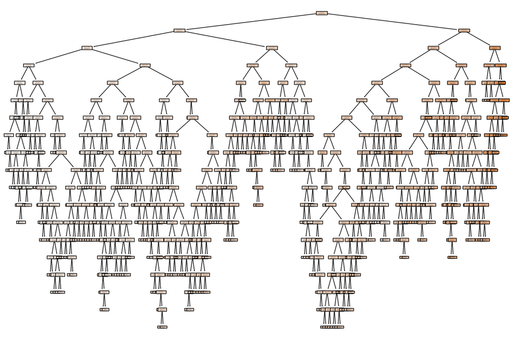

```python
from sklearn import tree
plt.figure(figsize=(15,10))
tree.plot_tree(dtr,filled=True)
```

```python
path = dtr.cost_complexity_pruning_path(xtrain, ytrain)
ccp_alphas, impurities = path.ccp_alphas, path.impurities
```

```python
ccp_alphas
```

```
array([0.00000000e+00, 1.14155251e+01, 1.14155251e+01, 1.14155251e+01,
       1.02739726e+02, 1.19835616e+02, 1.29644977e+02, 1.82648402e+02,
       1.82648402e+02, 1.82648402e+02, 2.31164384e+02, 2.85388128e+02,
       2.85388128e+02, 2.85388128e+02, 2.85388128e+02, 2.85388128e+02,
       2.85388128e+02, 2.85388128e+02, 3.80517504e+02, 4.10958904e+02,
       5.59360731e+02, 9.24657534e+02, 1.14155251e+03, 1.14155251e+03,
       1.14155251e+03, 1.14155251e+03, 1.14155251e+03, 1.14155251e+03,
       1.14155251e+03, 1.14155251e+03, 1.14155251e+03, 1.14155251e+03,
       1.14155251e+03, 1.14155251e+03, 1.14155251e+03, 1.38127854e+03,
       1.38127854e+03, 1.52207002e+03, 1.52207002e+03, 1.52207002e+03,
       1.71232877e+03, 1.78367580e+03, 2.23744292e+03, 2.30213090e+03,
       2.37823440e+03, 2.37823440e+03, 2.56849315e+03, 2.56849315e+03,
       2.56849315e+03, 2.56849315e+03, 2.56849315e+03, 3.01812329e+03,
       3.56735160e+03, 3.86064041e+03, 4.12100457e+03, 4.12100457e+03,
       4.56621005e+03, 4.56621005e+03, 4.56621005e+03, 4.56621005e+03,
       4.56621005e+03, 4.56621005e+03, 4.56621005e+03, 4.56621005e+03,
       4.80308219e+03, 5.03424658e+03, 5.77910959e+03, 6.08828006e+03,
       6.34183676e+03, 6.39649924e+03, 7.13470320e+03, 7.13470320e+03,
       7.13470320e+03, 7.13470320e+03, 7.13470320e+03, 7.52810959e+03,
       8.64041096e+03, 8.79066781e+03, 8.93699087e+03, 9.41596347e+03,
       9.51293760e+03, 9.51293760e+03, 1.02739726e+04, 1.02739726e+04,
       1.02739726e+04, 1.02739726e+04, 1.02739726e+04, 1.02739726e+04,
       1.15106545e+04, 1.21765601e+04, 1.22030323e+04, 1.31963470e+04,
       1.39840183e+04, 1.39840183e+04, 1.39840183e+04, 1.39840183e+04,
       1.47945205e+04, 1.60768645e+04, 1.60768645e+04, 1.82648402e+04,
       1.82648402e+04, 1.82648402e+04, 1.82648402e+04, 1.82648402e+04,
       1.82648402e+04, 1.85950868e+04, 1.86453577e+04, 1.91894977e+04,
       1.94824962e+04, 1.94824962e+04, 2.20559361e+04, 2.31164384e+04,
       2.31164384e+04, 2.37480974e+04, 2.37480974e+04, 2.52067841e+04,
       2.64921722e+04, 2.74086758e+04, 2.74923896e+04, 2.74923896e+04,
       2.76890696e+04, 2.85388128e+04, 2.85388128e+04, 2.85388128e+04,
       2.85388128e+04, 2.89576806e+04, 2.96917808e+04, 2.99514399e+04,
       3.06031294e+04, 3.08219178e+04, 3.15106545e+04, 3.15106545e+04,
       3.53426560e+04, 3.72945205e+04, 3.78996956e+04, 3.85078356e+04,
       4.10958904e+04, 4.10958904e+04, 4.10958904e+04, 4.11567732e+04,
       4.11567732e+04, 4.22146119e+04, 4.24771689e+04, 4.24771689e+04,
       4.38812785e+04, 4.60426180e+04, 4.82305936e+04, 4.82305936e+04,
       4.82305936e+04, 4.85962166e+04, 5.15125571e+04, 5.19418284e+04,
       5.20305116e+04, 5.47945205e+04, 5.49847793e+04, 5.75456621e+04,
       6.07452707e+04, 6.25114155e+04, 6.29280822e+04, 6.51160578e+04,
```

[output cut: 47 more lines]

```
       4.98123617e+06, 5.09296833e+06, 5.11738785e+06, 5.14783214e+06,
       6.19373820e+06, 6.23439878e+06, 6.43208613e+06, 6.66906966e+06,
       6.67207321e+06, 6.83081519e+06, 6.85761280e+06, 7.13114055e+06,
       7.16169685e+06, 7.43992696e+06, 7.59238126e+06, 7.92833628e+06,
       8.69218842e+06, 8.92814824e+06, 8.98632855e+06, 9.03781036e+06,
       9.37671233e+06, 9.42393376e+06, 1.01115805e+07, 1.02376984e+07,
       1.04889736e+07, 1.10372163e+07, 1.11462736e+07, 1.13896311e+07,
       1.22455479e+07, 1.22554110e+07, 1.22616292e+07, 1.41483348e+07,
       1.43831272e+07, 1.43916843e+07, 1.97876230e+07, 2.04751498e+07,
       2.07825782e+07, 2.12910252e+07, 2.22594575e+07, 2.24936686e+07,
       3.32835618e+07, 3.43579347e+07, 4.14850885e+07, 4.30524800e+07,
       4.45633557e+07, 4.94666042e+07, 5.46813374e+07, 6.86979575e+07,
       6.88732402e+07, 7.11289132e+07, 8.84427466e+07, 1.25770616e+08,
       1.62938674e+08, 2.79330776e+08, 2.86026862e+08, 8.09833648e+08,
       2.80088467e+09])
```

```python
dtrs = []
for ccp_alpha in ccp_alphas:
    dtr = DecisionTreeRegressor(random_state=0, ccp_alpha=ccp_alpha)
    dtr.fit(xtrain, ytrain)
    dtrs.append(dtr)
print("Number of nodes in the last tree is: {} with ccp_alpha: {}".format(
      dtrs[-1].tree_.node_count, ccp_alphas[-1]))
```

```
Number of nodes in the last tree is: 1 with ccp_alpha: 2800884673.4451585
```

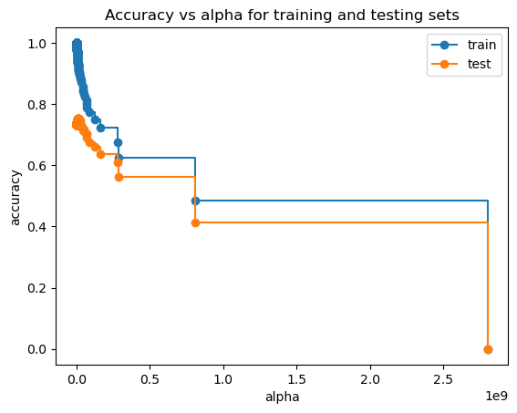

```python
train_scores = [dtr.score(xtrain, ytrain) for dtr in dtrs]
val_scores = [dtr.score(xval, yval) for dtr in dtrs]

fig, ax = plt.subplots()
ax.set_xlabel("alpha")
ax.set_ylabel("accuracy")
ax.set_title("Accuracy vs alpha for training and testing sets")
ax.plot(ccp_alphas, train_scores, marker='o', label="train",
        drawstyle="steps-post")
ax.plot(ccp_alphas, val_scores, marker='o', label="test",
        drawstyle="steps-post")
ax.legend()
plt.show()
```

```python
dtr = DecisionTreeRegressor(ccp_alpha=0.35)
dtr.fit(xtrain,ytrain)
```

```
DecisionTreeRegressor(ccp_alpha=0.35)
```

```python
dtr.score(xtrain,ytrain)
```

```
1.0
```

```python
dtr.score(xval,yval)
```

```
0.7255216703779271
```

```
[Text(0.6358800739898613, 0.9736842105263158, 'X[13] <= 0.25\nsquared_error = 5781935944.992\nsamples = 438\nvalue = 182139.813'),
```

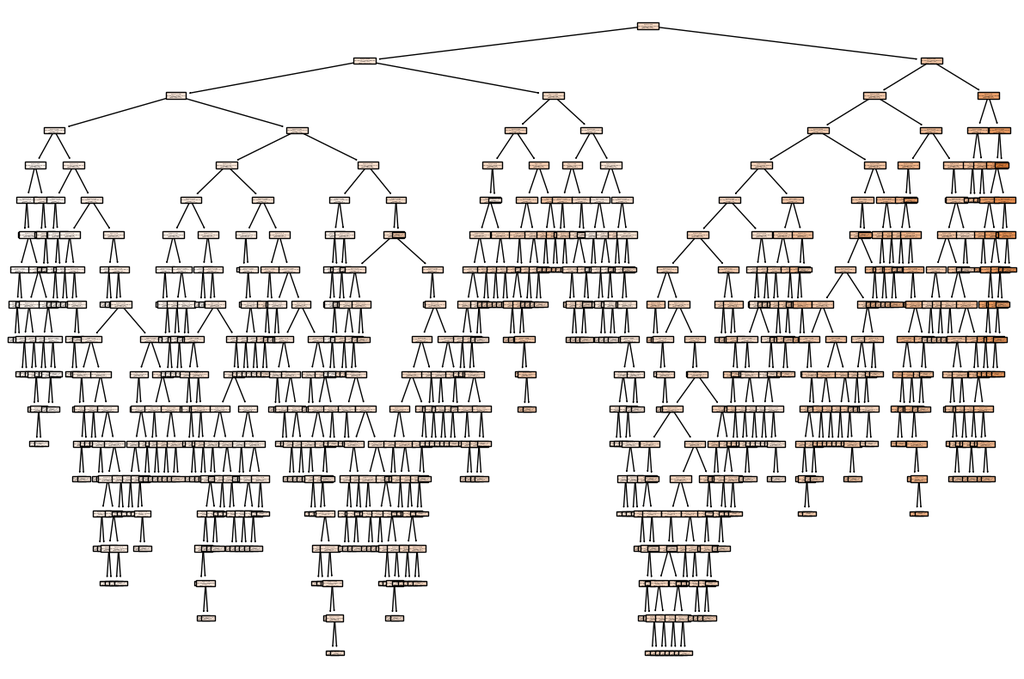

```python
from sklearn import tree
plt.figure(figsize=(15,10))
tree.plot_tree(dtr,filled=True)
```

```python
from sklearn.metrics import mean_squared_error

pred = dtr.predict(xval)
print ('RMSE is: \n', mean_squared_error(yval, pred))
```

[output not shown]

### Random Forest Regressor

```python
rfr.fit(xtrain,ytrain)
```

```
RandomForestRegressor()
```

```python
rfr.score(xtrain,ytrain)
```

```
0.9806959293209256
```

```python
rfr.score(xval,yval)
```

```
0.8138319440428292
```

```python
from sklearn.metrics import mean_squared_error

pred = rfr.predict(xval)
print ('RMSE is: \n', mean_squared_error(yval, pred))
```

[output not shown]

```python
rfr.fit(xtrain,ytrain)
preds = rfr.predict(test)
test = pd.DataFrame(test)
test.index = test.index + 1461
submission = pd.DataFrame({'Id': test.index ,'SalePrice': preds })
```

```python
submission.to_csv("submission.csv",index=False)
```

```python
submission
```

|  | Id | SalePrice |
| --- | --- | --- |
| 0 | 1461 | 131628.90 |
| 1 | 1462 | 153837.24 |
| 2 | 1463 | 180479.00 |
| 3 | 1464 | 185934.90 |
| 4 | 1465 | 222490.80 |
| ... | ... | ... |
| 1454 | 2915 | 93742.50 |
| 1455 | 2916 | 98037.58 |
| 1456 | 2917 | 140309.46 |
| 1457 | 2918 | 122102.50 |
| 1458 | 2919 | 233754.56 |

1459 rows × 2 columns